# Ch5: Resampling Methods

Philip Lin

2014.12.10

# Outline

- Preliminary
  - Overfitted and underfitted model
  - Prediction error of a model
- Cross Validation
  - Random split
  - Leave One Out Cross Validation (LOOCV)
  - K-fold Cross Validation
  - Conditional or Expected test error ?
  - A common mistake while implementing CV
- Bootstrap
- Maximum Likelihood thoery

# Overfitted and underfitted model

[ref](http://link.springer.com/article/10.1007%2Fs00038-008-7068-3#page-1)

$y = \beta_0 + \beta_1 x^3 + \epsilon$

# Prediction error of a model

$y = f(X) + \epsilon$

[ref](http://link.springer.com/article/10.1007%2Fs00038-008-7068-3#page-1)

# Prediction error of a model

- Intuitively, we want to minimize the prediction error against new data $\text{Err}_{\tau}=E_{X_0,Y_0}[L(Y^0, \hat{f}(X^0)|\tau]$
  - we call this conditional expection **testing error** or **generalization error**
  - Here the training set $\tau$ is fixed, and the test error refers to the error for this specific training set.
  - However, it’s not possible to estimate conditional error, given only the information in the same training set.
- If we can collect many training data set $\{\tau_1, \dots,\tau_m\}$, the expected prediction error can be obtained. $\text{Err}=E_{\tau}E_{X_0,Y_0}[L(Y^0, \hat{f}(X^0)|\tau]$
  - Estimation of test error for a particular training set is not easy in general, given just the data from that same training set. Instead, **Cross Validation** may provide reasonable estimates of **expected error** Err.

# Prediction error of a model

- Why we need additional testing data ?
  - since training error is not a good estimate of testing error.
- 100 simulated training set of size 50 each, as the model complexity is increased
  - light blue: training error
  - light red: conditional test error
  - solid blue: expected training error ($\bar{err}$)
  - solid red: expected test error ($Err$)

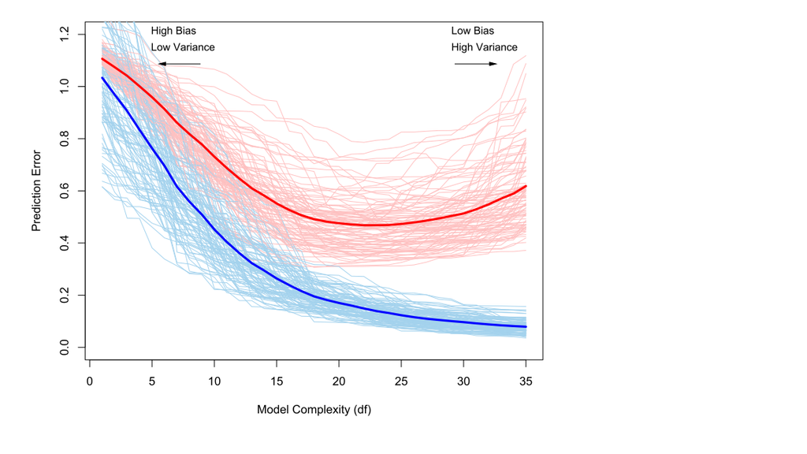

- U shape of $Err$

# Cross Validation: Random split

- $50\% ~~vs~~ 50\%$ case

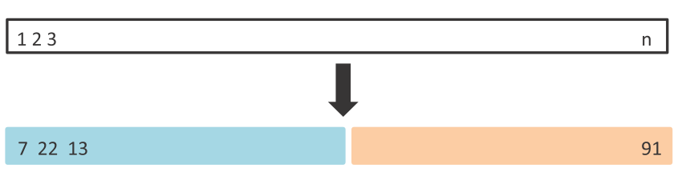

- Pros
  - We now have traning and testing… Oh yeah ~
- Cons
  - highly variable
    - depends on outlier or points with high leverage
  - train on fewer observations
    - overestimate the testing error rate

# Cross Validation: LOOCV

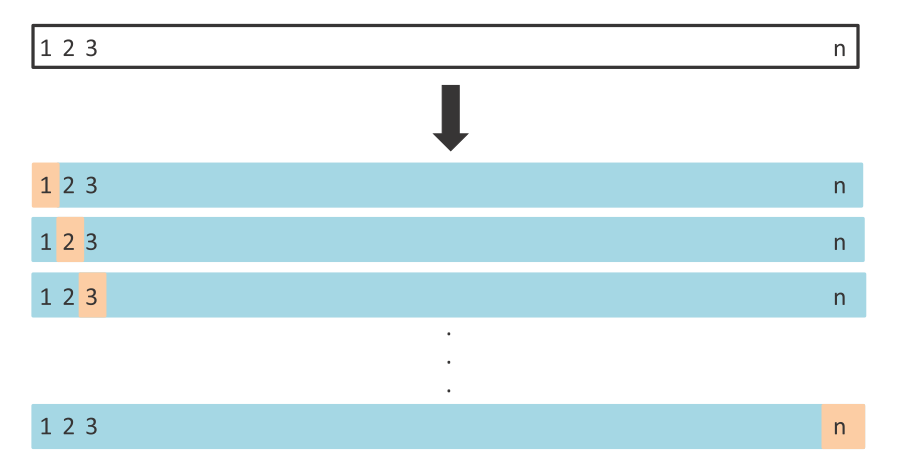

- Pros
  - far less bias, since LOOCV use almost all data as training
  - Special case: linear model $CV_{(n)}=\frac{1}{n}\sum_{i=1}^n\left( \frac{y_i-\hat{y}_i}{1-h_{ii}} \right)^2$ where $\hat{y}=Hy, h_{ii}=\frac{\partial\hat{y}_i}{\partial y_i}=\frac{1}{n}+\frac{(x_i-\bar{x})^2}{\sum_{j=1}^n(x_j-\bar{x})^2}, \frac{1}{n}\leq h_{ii}\leq 1$
- Cons
  - Each training are almost identical and thus outputs are highly correlated with each other.
    - Mean of many highly correlated quantities has **higher variance** than does the mean of many quantities that are not as highly correlated.
  - no randomness
  - computational burden

# Cross Validation: K-fold

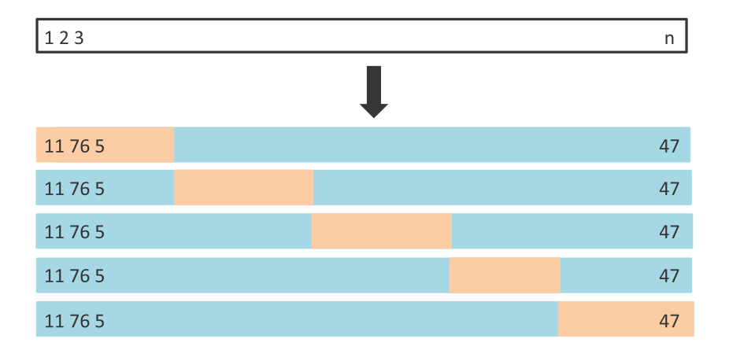

- K-fold CV, split randomly or split by order (K=5 in this plot)
- Pros
  - Overlap between the training sets in each model is smaller, outputs of $k$ fitted models that are some what less correlated with each other.
- Cons
  - Computational burden (?)
  - …
- K=5 ? k=10? k=20?

# Conditional or Expected test error ?

$\text{Err}_{\tau}=E_{X_0,Y_0}[L(Y^0, \hat{f}(X^0)|\tau]$

$\text{Err}=E_{\tau}E_{X_0,Y_0}[L(Y^0, \hat{f}(X^0)|\tau]$

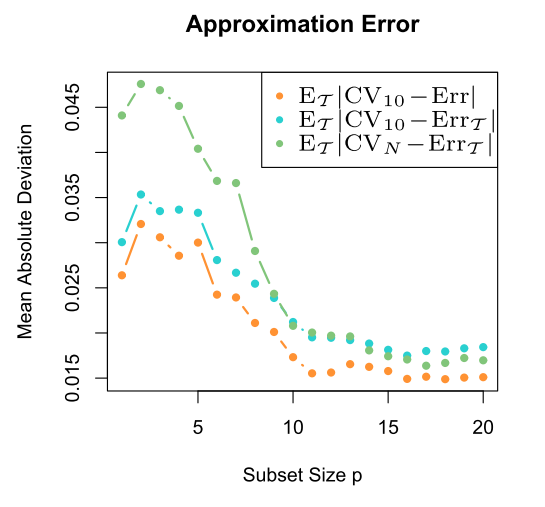

# A common mistake while implementing CV

Consider $N=50$ in two equal-sized classes, and $p=5000$ (standard Gaussian) that are independent of the class labels. The true test error rate of any classifier is $50\%$

$L(Y,\hat{f}(X))=\frac{1}{n}\sum_i I\{Y_i\neq \hat{f}(X_i)\} 100\%$

- Approach I
  1. Screen the predictors: find a subset of ‘good’ predictors that show strong correlation (univariate) with the class labels. (choose first $100$ predictors)
  2. Using these $100$ predictors to build a multivariate classifier.
  3. Use CV to estimate the unknown tuning parameters and to estimate the prediction error of the final model.
- Approach II
  - Divide the samples into $K$ CV folds at random.
  - for each fold $k=1,2,\dots,K$
    1. find a subset of ‘good’ predictors that show strong correlation (univariate) with the class labels, using all of the samples except those in fold $k$.
    2. Using these $100$ predictors to build a multivariate classifier, using all of the samples except those in fold $k$.
    3. Use the classifier to predict the class labels for the samples in fold $k$

# A common mistake while implementing CV

Consider $N=50$ in two equal-sized classes, and $p=5000$ (standard Gaussian) that are independent of the class labels. The true test error rate of any classifier is $50\%$

$L(Y,\hat{f}(X))=\frac{1}{n}\sum_i I\{Y_i\neq \hat{f}(X_i)\} 100\%$

- Wrong way (avg CV = $3\%$)
  1. Screen the predictors: find a subset of ‘good’ predictors that show strong correlation (univariate) with the class labels. (choose first $100$ predictors)
  2. Using these $100$ predictors to build a multivariate classifier.
  3. Use CV to estimate the unknown tuning parameters and to estimate the prediction error of the final model.
- Right way
  - Divide the samples into $K$ CV folds at random.
  - for each fold $k=1,2,\dots,K$
    1. find a subset of ‘good’ predictors that show strong correlation (univariate) with the class labels, using all of the samples except those in fold $k$.
    2. Using these $100$ predictors to build a multivariate classifier, using all of the samples except those in fold $k$.
    3. Use the classifier to predict the class labels for the samples in fold $k$

# Bootstrap

- Training set $Z=(z_1,z_2,\dots,z_n), z_i=(x_i, y_i)$
  1. Randomly draw dataset with replacement from the original training set.
  2. Do this $B$ times to obtain $B$ bootstrap datasets
  3. Refit the model to each of the bootstrap datasets

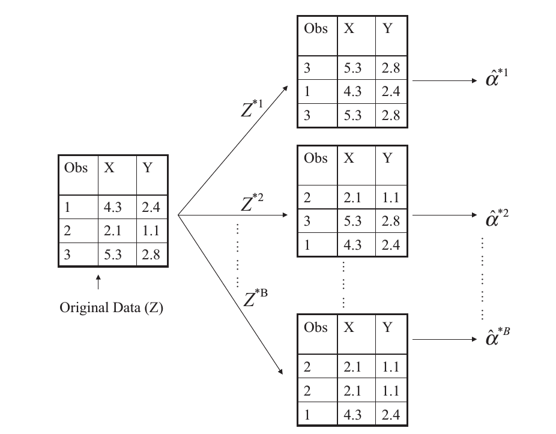

# Bootstrap: example

```
Call:
glm(formula = default ~ ., family = binomial("logit"), data = Default)

Deviance Residuals:
    Min       1Q   Median       3Q      Max
-2.4691  -0.1418  -0.0557  -0.0203   3.7383

Coefficients:
              Estimate Std. Error z value Pr(>|z|)
(Intercept) -1.087e+01  4.923e-01 -22.080  < 2e-16 ***
studentYes  -6.468e-01  2.363e-01  -2.738  0.00619 **
balance      5.737e-03  2.319e-04  24.738  < 2e-16 ***
income       3.033e-06  8.203e-06   0.370  0.71152
---
Signif. codes:  0 '***' 0.001 '**' 0.01 '*' 0.05 '.' 0.1 ' ' 1

(Dispersion parameter for binomial family taken to be 1)

    Null deviance: 2920.6  on 9999  degrees of freedom
Residual deviance: 1571.5  on 9996  degrees of freedom
AIC: 1579.5

Number of Fisher Scoring iterations: 8
```

```
ORDINARY NONPARAMETRIC BOOTSTRAP


Call:
boot(data = Default, statistic = boot.fn, R = 1000)


Bootstrap Statistics :
         original        bias     std. error
t1* -1.086905e+01 -3.546116e-02 5.105579e-01
t2* -6.467758e-01  2.157987e-03 2.367434e-01
t3*  5.736505e-03  1.665336e-05 2.406843e-04
t4*  3.033450e-06  1.659800e-07 8.180066e-06
```

# Questions that I didn’t answer you…

- Q: What does the “std” means in the summary table ? When I colloect a set of sample to do point estimation, is it reasonable to produce a standard error ?
- Q: What is most efficient in MLE theory ?

# Maximum Likelihood Theory

- $P_{\theta}(x)$ probability density function
- $L_x(\theta)$ likelihood function $P_{\theta}(x) = L_x(\theta)$ We can find local/global maximum $\hat{\theta}(X_n)$ that maximize $L_x(\theta)$
- Asymptotic theory of MLE $X_1, \dots, X_n ~ \underset{\sim}{{\tiny i.i.d}} ~ P({x;\theta_0})$ then, with some regular conditions $\sqrt{n}(\hat{\theta}(X_n)-\theta_0) \rightarrow N(0, I^{-1}(\theta_0))$ where $I(\theta)=-E\left[\frac{\partial^2 l(x;\theta)}{\partial\theta^2}\right]$
- Cramer-Rao Lower Bound

The variace of any unbiased estimator $\tilde{\theta}$ of $\theta$ is bounded by information. $\text{var}(\tilde{\theta})\geq\frac{1}{I(\theta)}$

- efficiency of an estimator $e(\hat{\theta}) = \frac{I(\theta)^{-1}}{\text{var}(\hat{\theta})}$

```
Call:
lm(formula = mpg ~ horsepower - 1, data = Auto)

Residuals:
    Min      1Q  Median      3Q     Max
-28.451  -5.033   5.609  15.185  35.716

Coefficients:
           Estimate Std. Error t value Pr(>|t|)
horsepower 0.178840   0.006648    26.9   <2e-16 ***
---
Signif. codes:  0 '***' 0.001 '**' 0.01 '*' 0.05 '.' 0.1 ' ' 1

Residual standard error: 14.65 on 391 degrees of freedom
Multiple R-squared:  0.6492,    Adjusted R-squared:  0.6483
F-statistic: 723.7 on 1 and 391 DF,  p-value: < 2.2e-16
```

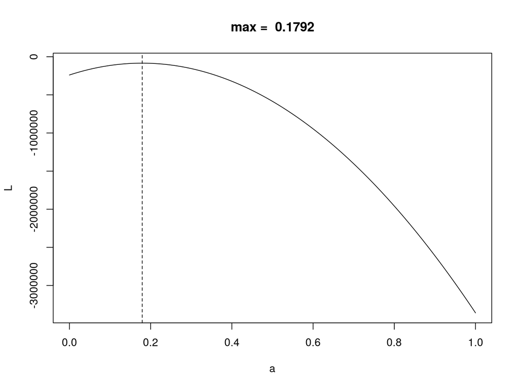

# What are we going to do ?

$y = f(X) + \epsilon$

- Unsupervised learning
  - Unsupervised Learning (Ch10)
- Supervised learning (Inference purpose)
  - Linear regression (Ch3)
  - Classification (Ch4)
  - Resampling method (Ch5)
  - Linear model selection and regularization (Ch6)
  - Moving beyond linearity (Ch7)
- Supervised learning (Prediction purpose)
  - Tree based method (Ch8)
  - Support Vector Machine (Ch9)